# NYC Electricity Demand Prediction - EDA and Data Preprocessing

### Summary

#### Aim

- Clean and format data for input into machine learning models that predict hourly electricity consumption in NYC (MWh)
- Tasks:
  1. Variable selection
  2. Filter for 2016 - 2019 (excl. COVID impacts)
  3. Manage NAs/blank cells
  4. Outlier detection
  5. Feature Engineering:
     - 24hr lagged MWh variable
     - Weekday/weekend
     - Seasons
  6. EDA: covariance and ANOVA analysis

#### Raw Data

- TimeFrame: Jul 2015 - Nov 2022
- Features:
  - Monthly & daily averages, and hourly values for weather variables in NYC (124 variables incl. dry/wet temp, wind speed, humidity etc.) (Source: National Oceanic Atmospheric Association (NOAA))
- Dependent Variable:
  - Hourly electricity consumption for New York City (NYC) (MWh) (Source: U.S. Energy Information Administration)

#### Covariance Analysis Summary

- Weak linear relationships between numerical variables should be considered for regression model configuration
- ANOVA of categorical variables suggest a statistically significant relationship with MWh

#### 1. Weather

- View columns and remove irrelevant variables e.g. daily, monthly
- Create separate date and hour columns
- Remove duplicated dates/hours
- Convert columns to date/numeric
- Filter for only 2016 - 2019

```r
#print(colnames(weather))
weather_filtered <- weather %>%
  select(-starts_with("Daily"), -starts_with("Monthly"), -starts_with("ShortDuration"),-starts_with("Backup")) %>%
  select(-c(1,3:14,17,21,22,24:26,29:36))
# create date and hour columns
weather_filtered <- weather_filtered %>%
  separate(DATE, into = c("date", "hour"), sep = "T")
weather_filtered$hour <- substr(weather_filtered$hour, 1, 2)
# remove duplicates for the date and hour columns
weather_filtered <- weather_filtered[!duplicated(weather_filtered[, c("date", "hour")], fromFirst = TRUE), ]
# convert columns to numeric
weather_filtered[, 2:10] <- lapply(weather_filtered[, 2:10], as.numeric)
# convert date column to date format
weather_filtered$date <- as.Date(weather_filtered$date)
# filter for only 2016 - 2019
weather_filtered <- weather_filtered %>%
  filter(year(date) %in% c(2016, 2017, 2018, 2019))
print(colnames(weather_filtered))
```

```
##  [1] "date"                     "hour"
##  [3] "HourlyDryBulbTemperature" "HourlyPrecipitation"
##  [5] "HourlyPressureChange"     "HourlyPressureTendency"
##  [7] "HourlyRelativeHumidity"   "HourlyStationPressure"
##  [9] "HourlyWindGustSpeed"      "HourlyWindSpeed"
```

#### 1.1 Weather NAs

```r
# show NAs
nas <- colSums(is.na(weather_filtered))
print(nas/nrow(weather_filtered)*100)
```

```
##                     date                     hour HourlyDryBulbTemperature
##                0.0000000                0.0000000                0.1370763
##      HourlyPrecipitation     HourlyPressureChange   HourlyPressureTendency
##               15.1754862               72.2163521               72.2163521
##   HourlyRelativeHumidity    HourlyStationPressure      HourlyWindGustSpeed
##                0.1456435                1.3393495               85.8754319
##          HourlyWindSpeed
##               16.3663364
```

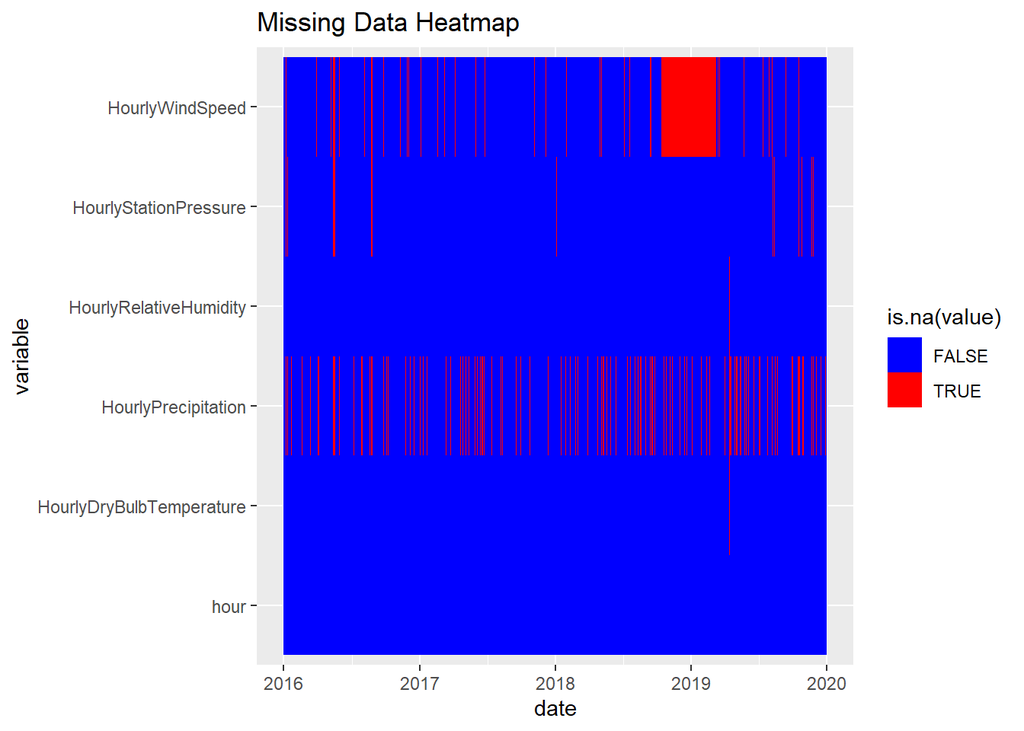

```r
# remove HourlyPressureChange, HourlyPressureTendency, HourlyWindGustSpeed because of high percentage of NAs
weather_filtered <- weather_filtered %>%
  select(-HourlyPressureChange,-HourlyPressureTendency,-HourlyWindGustSpeed)
# check location of remaining columns with NAs
melted_df <- melt(weather_filtered, id.vars = "date")
ggplot(melted_df, aes(x = date, y = variable, fill = is.na(value))) +
  geom_tile() +
  scale_fill_manual(values = c("TRUE" = "red", "FALSE" = "blue")) +
  labs(title = "Missing Data Heatmap")
```

```r
# remove HourlyWindSpeed
weather_filtered <- weather_filtered %>%
  select(-HourlyWindSpeed)
#fill precipitation NAs with 0
na_positions <- which(is.na(weather_filtered$HourlyPrecipitation) & lag(weather_filtered$HourlyPrecipitation) > 0 & lead(weather_filtered$HourlyPrecipitation) > 0)
# linear interpolation for NAs at valid positions
weather_filtered$HourlyPrecipitation_filled <- weather_filtered$HourlyPrecipitation
weather_filtered$HourlyPrecipitation_filled[na_positions] <- approx(x = which(!is.na(weather_filtered$HourlyPrecipitation)),
                                               y = weather_filtered$HourlyPrecipitation[!is.na(weather_filtered$HourlyPrecipitation)],
                                               xout = na_positions)$y
# Replace remaining NAs with 0
weather_filtered$HourlyPrecipitation_filled[is.na(weather_filtered$HourlyPrecipitation_filled)] <- 0
#replace and remove column
weather_filtered$HourlyPrecipitation <- weather_filtered$HourlyPrecipitation_filled
weather_filtered <- weather_filtered %>%
  select(-HourlyPrecipitation_filled)
#fill remaining NAs using linear interpolation
na_columns <- colnames(weather_filtered)[colSums(is.na(weather_filtered)) > 0]
weather_filtered[na_columns] <- na.approx(weather_filtered[na_columns])
#check nas
check_nas <- colSums(is.na(weather_filtered))
print(check_nas)
```

```
##                     date                     hour HourlyDryBulbTemperature
##                        0                        0                        0
##      HourlyPrecipitation   HourlyRelativeHumidity    HourlyStationPressure
##                        0                        0                        0
```

#### 1.2 Weather Outlier Detection

- Detect outliers for each variable using IQR and threshold value of 1.5:
  - Low outliers = Q1 - 1.5 * IQR
  - High outliers = Q3 + 1.5 * IQR
- Precipitation outliers are mainly due to the fact that the majority of precipation values are 0 (most of the time it’s not raining). A visual inspection of the graph shows the majority of the outliers are within reasonable bounds and occur at similar times of the year. Even the two largest outliers are within realms of possibility and therefore are not likely to represent technical malfunction. Therefore they are left in the dataset.
- Similarly the extereme pressure outliers appear to occur at similar dates in the year and therefore not removed.

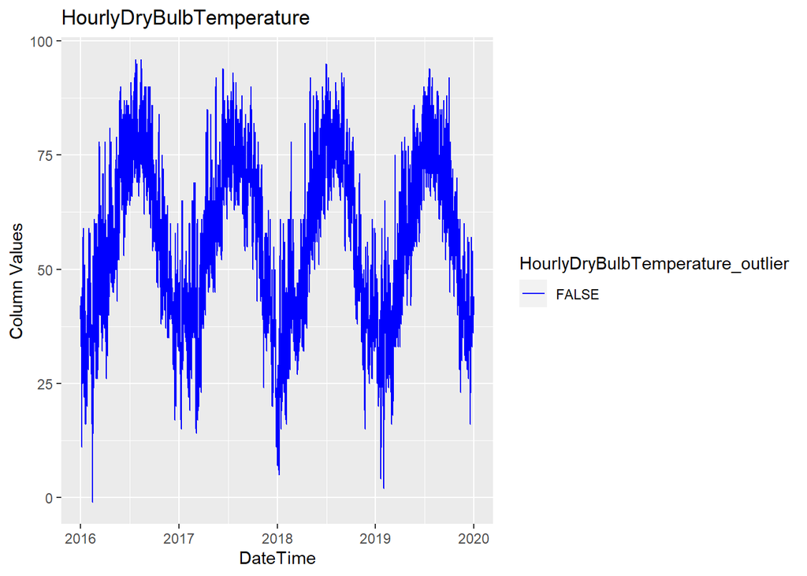

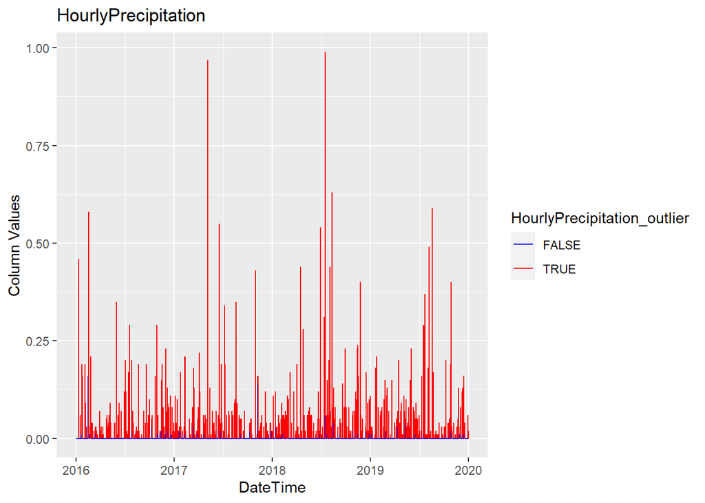

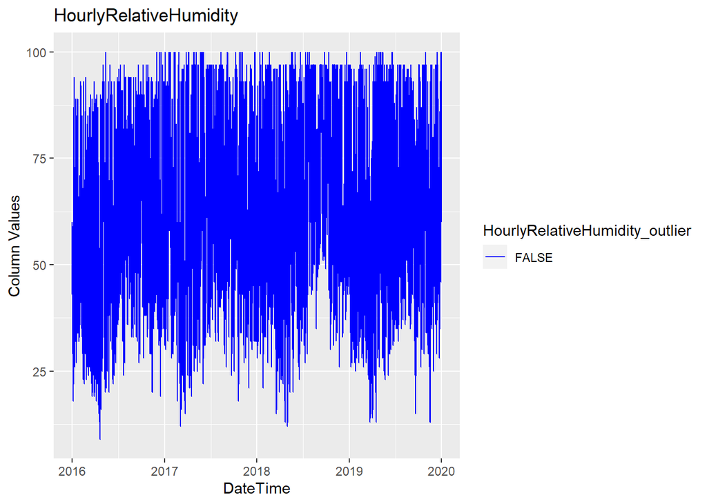

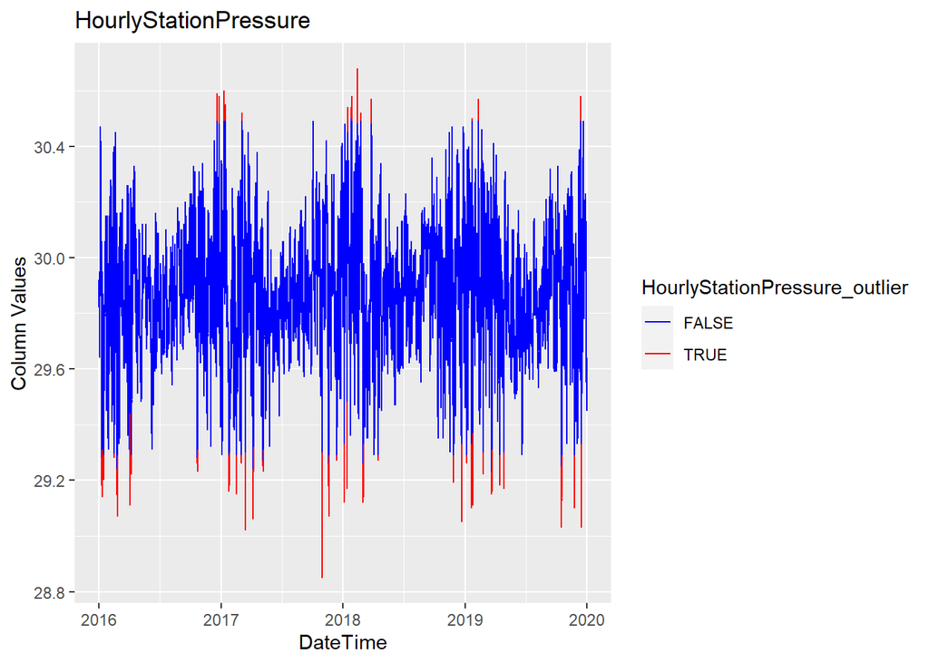

```r
#create duplicate df for plotting
weather_plot <- data.frame(weather_filtered)
#define function to classify rows
detect_and_classify_outliers <- function(column) {
  # Calculate IQR
  q <- quantile(column, c(0.25, 0.75))
  iqr <- q[2] - q[1]
  # Define upper and lower bounds
  lower_bound <- q[1] - 1.5 * iqr
  upper_bound <- q[2] + 1.5 * iqr
  # Identify and classify outliers
  outliers <- column < lower_bound | column > upper_bound

  return(outliers)
}

# Loop through columns
for (col in 3:6) {
  column_name <- names(weather_plot)[col]
  # Detect and classify outliers for each column
  weather_plot[paste(column_name, "outlier", sep = "_")] <- detect_and_classify_outliers(weather_plot[[col]])
}
#combine date and time columns
weather_plot$DateTime <- ymd(weather_plot$date) + hours(weather_plot$hour - 1)
# plot outliers graph function for each variable
plot_with_outliers <- function(df, col_name) {
  ggplot(df, aes(x = DateTime, y = .data[[col_name]], color = .data[[paste(col_name, "outlier", sep = "_")]], group = 1)) +
    geom_line() +
    labs(title = col_name, x = "DateTime", y = "Column Values") +
    scale_color_manual(values = c("FALSE" = "blue", "TRUE" = "red"))
}

# Loop through columns  and create a plot for each
for (col in 3:6) {
  column_name <- names(weather_plot)[col]
  # Create a plot for each column
  plot <- plot_with_outliers(weather_plot, column_name)
  # Print the plot
  print(plot)
}
```

```r
# count number of days with 24 hrs
demand_24hrs <- table(table(weather_filtered$date))
#print(demand_24hrs)
# Create new date range
weather_filtered$DateTime <- ymd(weather_filtered$date) + hours(weather_filtered$hour - 1)
weather_filtered$DateTime <- as.POSIXct(weather_filtered$DateTime)
min_date <- as.POSIXct("2016-01-01 00:00:00")
max_date <- as.POSIXct("2019-12-31 23:00:00")
date_range_complete <- seq.POSIXt(min_date, max_date, by = "hour")
date_range_complete <- data.frame(DateTime = date_range_complete)
# Merge to keep date range complete
weather_filtered <- merge(date_range_complete, weather_filtered, by = "DateTime", all.x = TRUE)
# fill missing values from last known
weather_filtered <- weather_filtered %>%
  mutate_at(vars(4:7), ~ na.locf(., fromLast = TRUE))
# separate date time and drop old date time columns
weather_filtered <- weather_filtered %>%
  select(-date, -hour)
weather_filtered <- weather_filtered %>%
  separate(DateTime, into = c("date", "hour"), sep = " ")
weather_filtered$hour <- substr(weather_filtered$hour, 1, 2)
```

#### 2. Demand

- Create date and hour columns in same format as weather df
- Filter for 2016 - 2019

```r
# create date and hour columns
split_datetime <- strsplit(demand$Category, " ")
demand$date <- sapply(split_datetime, "[[", 1)
demand$hour <- sapply(split_datetime, "[[", 2)
demand$hour <- gsub("H", "", demand$hour)
demand <- demand %>% select(-Category)
#convert data and hour column to same format as weather_df
demand_date <- demand %>%
  mutate(date = format(as.Date(date, format = "%m/%d/%Y"), format = "%Y-%m-%d"))
# filter years
demand_date <- demand_date %>%
  filter(year(date) %in% c(2016, 2017, 2018, 2019))
```

#### 2.1 Demand NAs

- No NAs found

```r
#check for NAs
print(colSums(is.na(demand)))
```

```
##  MWh date hour
##    0    0    0
```

#### 2.2 Outliers

- Detect outliers using IQR and threshold value of 1.5:
  - Low outliers = Q1 - 1.5 * IQR
  - High outliers = Q3 + 1.5 * IQR
- Low outliers: only 3 values of 0. Likely due to technical issue with measurement. Therefore, fill-in 0 values with linear interpolation.
- High outliers: as the graph below shows, the high outliers appear to be in the summer months, and are consistently high each year. Therefore, although representing outliers for the whole dataset, they are likely not outliers in the sense of technical errors etc. and so will not be removed from the dataset.

[figure not shown]

```r
# identify outliers
Q1 <- quantile(demand_date$MWh, 0.25)
Q3 <- quantile(demand_date$MWh, 0.75)
IQR <- Q3 - Q1
threshold <- 1.5
low_outliers <- demand_date[demand_date$MWh < (Q1 - threshold * IQR), ]
# use linear interpolation to fill 0 values
demand_date$MWh[demand_date$MWh == 0] <- NA
demand_date$MWh <- na.approx(demand_date$MWh)
# identify high outliers
high_outliers <- demand_date[demand_date$MWh > (Q3 + threshold * IQR), ]
# plot high outliers and normal
high_outliers$source <- "high_outliers"
demand_plot <- data.frame(demand_date)
demand_plot$source <- "NYC_Elec"
demand_plot <- left_join(demand_plot, high_outliers, by = c("MWh", "date", "hour"), suffix = c("_NYC_Elec", "_high_outliers"))
demand_plot <- demand_plot %>%
  mutate(source = ifelse(is.na(source_high_outliers), source_NYC_Elec, source_high_outliers)) %>%
  select(-source_NYC_Elec, -source_high_outliers)
demand_plot$hour <- as.numeric(demand_plot$hour)
demand_plot$DateTime <- ymd(demand_plot$date) + hours(demand_plot$hour - 1)
demand_plot <- demand_plot %>% select(-date,-hour)
demand_plot <- demand_plot %>% arrange(source, DateTime)
ggplot(demand_plot, aes(x = DateTime, y = MWh, colour = source, group = 1)) +
  geom_line() +
  labs(x = "Datetime", y = "MWh", title = "New York City Hourly Electrcity Demand (MWh) (July 2015 - November 2022)") +
  scale_color_manual(values = c("red", "blue"))
```

#### 2.3 Lagged Demand Variable

- Add 24 hr lagged electricity demand variable

```r
# create lagged 24hr variable
demand_lag <- demand_date %>%
  arrange(date, hour) %>%
  mutate(lagged_MWh = ifelse(row_number() <= 24, MWh, lag(MWh, n = 24)))
```

#### 3. Merge datasets

```r
master <- merge(weather_filtered, demand_lag, by.x = c("date", "hour"), by.y = c("date", "hour"), all = FALSE)
```

*Feature engineering:* Add weekend/weekday and seasons categorical variables

```r
# add days of the week
master$date <- as.Date(master$date)
master$dayofweek <- weekdays(master$date)
master$weekdayorweekend <- ifelse(master$dayofweek %in% c("Saturday", "Sunday"), "Weekend", "Weekday")
master <- master %>% select(-dayofweek)

#add season
season_func <- function(date) {
  month <- as.integer(format(date, "%m"))

  if (month >= 3 && month <= 5) {
    return("Spring")
  } else if (month >= 6 && month <= 8) {
    return("Summer")
  } else if (month >= 9 && month <= 11) {
    return("Autumn")
  } else {
    return("Winter")
  }
}
master$season <- sapply(master$date, season_func)
#remove hourly reference from variable titles
colnames(master) <- sub("Hourly", "", colnames(master))
```

#### 4. Correlation Analysis

#### 4.1 Pearson Correlation Coefficent Matrix

- Plot a correlation matrix to analyse linear relationships between numeric variables
- Result: Except lagged MWh, plots show weak linear relationships
- Weak relationships shown in graphs below

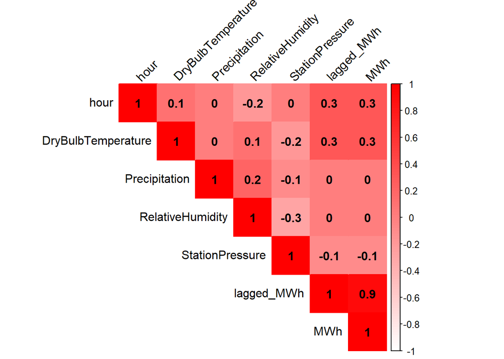

```r
## create a pearson correlation matrix and plot
master_cor <- master %>% select(-date,-weekdayorweekend,-season)
master_cor <- master_cor[, c(1:5, 7, 6)]
master_cor$hour <- as.numeric(master_cor$hour)
cor_matrix <- round(cor(master_cor), 1)
corrplot(
  cor_matrix,
  method = "color",
  col = colorRampPalette(c("white", "red"))(100),
  type = "upper",
  tl.col = "black",
  tl.srt = 45,
  addCoef.col = "black",
)
```

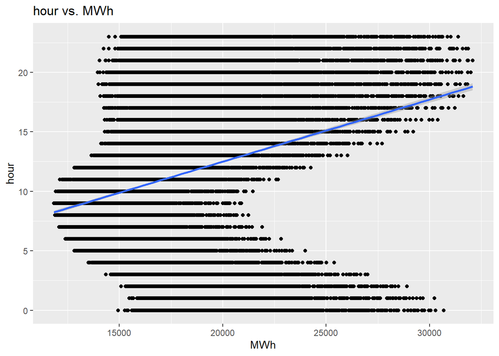

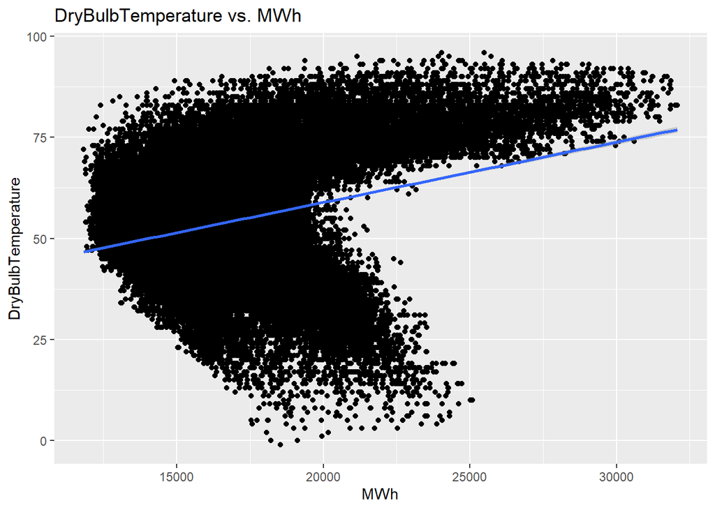

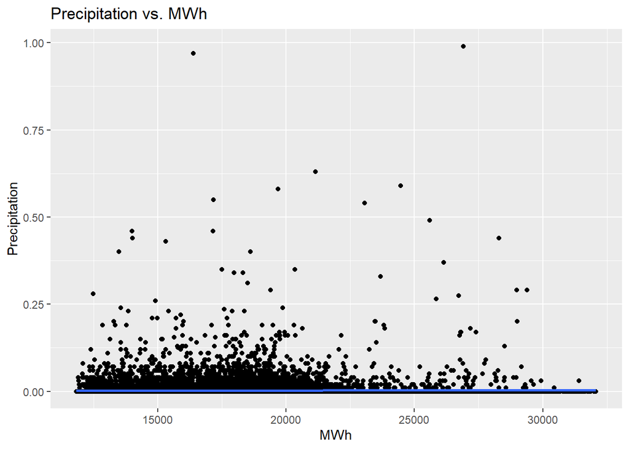

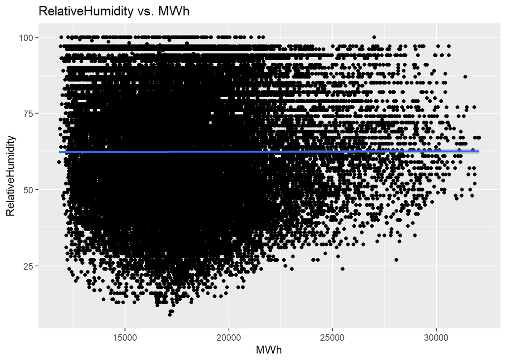

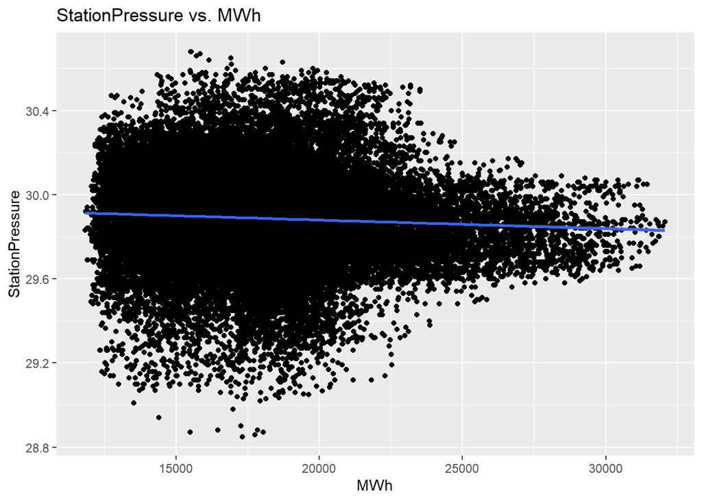

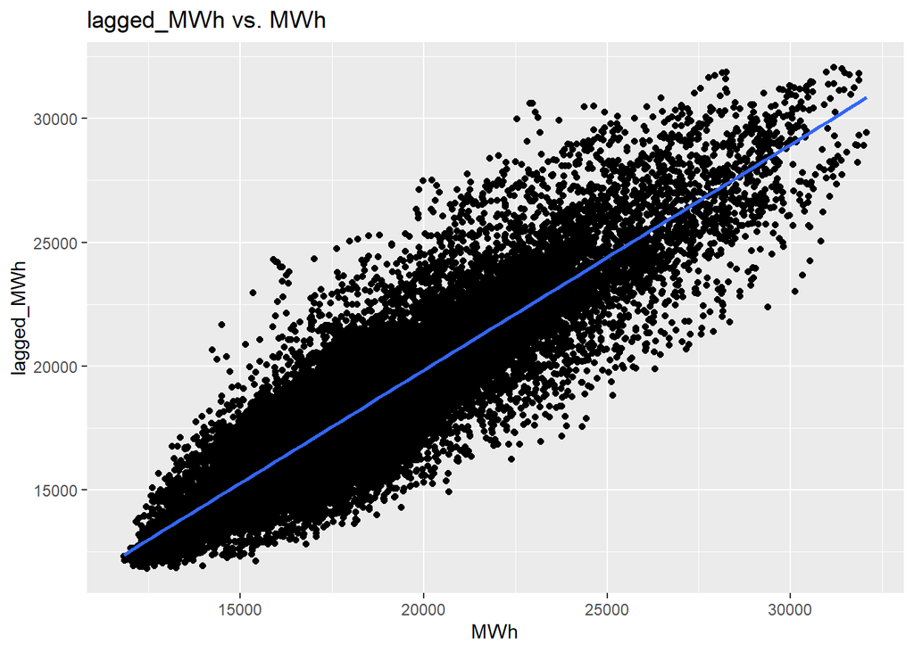

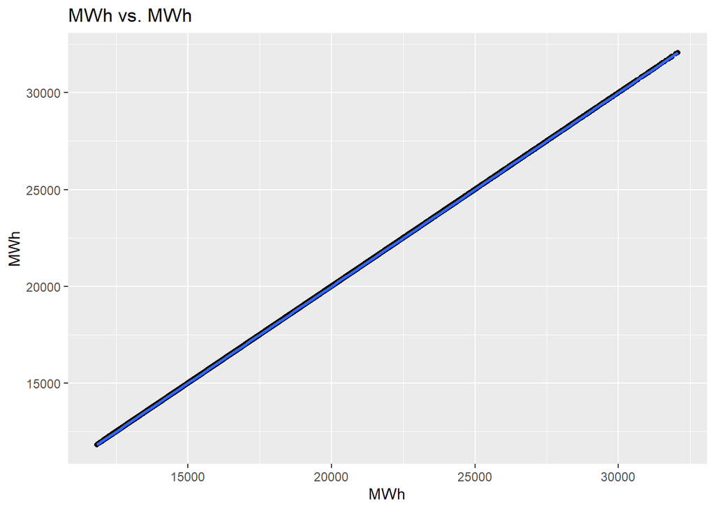

```r
plots_list <- list()

for (i in 1:7) {
  p <- ggplot(master_cor, aes(x = master_cor[, 7], y = master_cor[, i])) +
    geom_point() +
    geom_smooth(method = "lm") +
    labs(x = names(master_cor)[7], y = names(master_cor)[i]) +
    ggtitle(paste(names(master_cor)[i], "vs.", names(master_cor)[7]))

  plots_list[[i]] <- p
}

for (i in 1:length(plots_list)) {
  print(plots_list[[i]])
}
```

#### 4.3 Perform ANOVA on categorical variables vs MWh

- Result: the low p values suggest a statistically significant effect of these variables on the dependent variable

```r
# perform ANOVA analysis for the categorical variables
anova_weekdayorweekend <- aov(MWh ~ weekdayorweekend, data = master)
anova_season <- aov(MWh ~ season, data = master)
print(summary(anova_weekdayorweekend))
```

```
##                     Df    Sum Sq   Mean Sq F value Pr(>F)
## weekdayorweekend     1 1.352e+10 1.352e+10    1245 <2e-16 ***
## Residuals        35062 3.808e+11 1.086e+07
## ---
## Signif. codes:  0 '***' 0.001 '**' 0.01 '*' 0.05 '.' 0.1 ' ' 1
```

```r
print(summary(anova_season))
```

```
##                Df    Sum Sq   Mean Sq F value Pr(>F)
## season          3 8.934e+10 2.978e+10    3423 <2e-16 ***
## Residuals   35060 3.050e+11 8.700e+06
## ---
## Signif. codes:  0 '***' 0.001 '**' 0.01 '*' 0.05 '.' 0.1 ' ' 1
```